# P4_MartinOkanik

11. **The `interval` argument can be used to generate confidence or prediction intervals. Create a new object called `y_pred_95` using `predict()` (again with the `pred_dat` data) with the `interval` argument set to “confidence”. What is in this object?**

```r
y_pred_95 <- lm_ses %>% predict(pred_dat, interval = "confidence")
tail(y_pred_95)
```

```
##            fit       lwr       upr
## 996  -3.258123 -5.394117 -1.122130
## 997  -3.296125 -5.435063 -1.157188
## 998  -3.334127 -5.476009 -1.192246
## 999  -3.372129 -5.516956 -1.227303
## 1000 -3.410131 -5.557903 -1.262360
## 1001 -3.448133 -5.598850 -1.297417
```

12. **Create a data frame with 4 columns: `medv`, `lstat`, `lower`, and `upper`.**

```r
preds <- tibble(lstat = pred_dat$lstat, medv = y_pred_95[,1] , lower = y_pred_95[,2], upper = y_pred_95[,3])

preds
```

```
## # A tibble: 1,001 × 4
##    lstat  medv lower upper
##    <dbl> <dbl> <dbl> <dbl>
##  1  0     34.6  33.4  35.7
##  2  0.04  34.5  33.4  35.6
##  3  0.08  34.5  33.4  35.6
##  4  0.12  34.4  33.3  35.5
##  5  0.16  34.4  33.3  35.5
##  6  0.2   34.4  33.3  35.5
##  7  0.24  34.3  33.2  35.4
##  8  0.28  34.3  33.2  35.4
##  9  0.32  34.2  33.2  35.3
## 10  0.36  34.2  33.1  35.3
## # … with 991 more rows
## # ℹ Use `print(n = ...)` to see more rows
```

13. **Add a `geom_ribbon()` to the plot with the data frame you just made. The ribbon geom requires three aesthetics: `x` (`lstat`, already mapped), `ymin` (`lower`), and `ymax` (`upper`). Add the ribbon below the `geom_line()` and the `geom_points()` of before to make sure those remain visible. Give it a nice colour and clean up the plot, too!**

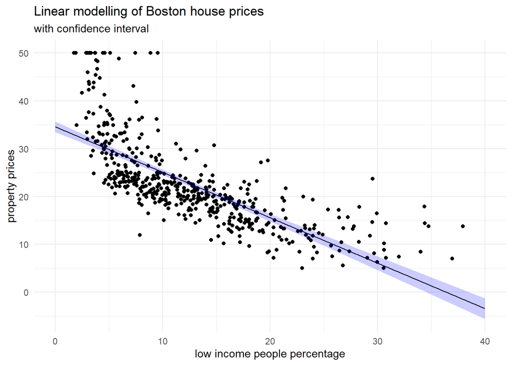

```r
Boston %>%
  ggplot(aes(x = lstat, y = medv)) +
  geom_point() +
  geom_line(data = preds) +
  geom_ribbon(aes(ymin = lower, ymax = upper), data = preds, fill = "blue", alpha = 0.2) +
  labs(title = "Linear modelling of Boston house prices",
       x = "low income people percentage",
       y = "property prices",
       subtitle = "with confidence interval") +
  theme_minimal()
```

14. **Explain in your own words what the ribbon represents.**

the ribbon represents the 95% confidence interval of the fitted line. Error estimates of the fit can be obtained by e.g. bootstrapping. Exact error (we really mean variance) estimate can be obtained if one could make arbitrary many samples from the underlying distribution and see the distribution of model parameters resulting from these various samples.

15. **Do the same thing, but now with the prediction interval instead of the confidence interval**

```r
y95 <- lm_ses %>% predict(pred_dat, interval = "prediction")
tail(y95)
```

```
##            fit       lwr      upr
## 996  -3.258123 -15.65551 9.139265
## 997  -3.296125 -15.69402 9.101770
## 998  -3.334127 -15.73253 9.064277
## 999  -3.372129 -15.77104 9.026784
## 1000 -3.410131 -15.80955 8.989292
## 1001 -3.448133 -15.84807 8.951800
```

```r
tail(y95[,3])
```

```
##      996      997      998      999     1000     1001
## 9.139265 9.101770 9.064277 9.026784 8.989292 8.951800
```

```r
preds_pred <- tibble(lstat = pred_dat$lstat, medv = y95[,1] , lower = y95[,2], upper = y95[,3])

preds_pred
```

```
## # A tibble: 1,001 × 4
##    lstat  medv lower upper
##    <dbl> <dbl> <dbl> <dbl>
##  1  0     34.6  22.3  46.8
##  2  0.04  34.5  22.3  46.8
##  3  0.08  34.5  22.2  46.7
##  4  0.12  34.4  22.2  46.7
##  5  0.16  34.4  22.1  46.7
##  6  0.2   34.4  22.1  46.6
##  7  0.24  34.3  22.1  46.6
##  8  0.28  34.3  22.0  46.5
##  9  0.32  34.2  22.0  46.5
## 10  0.36  34.2  22.0  46.5
## # … with 991 more rows
## # ℹ Use `print(n = ...)` to see more rows
```

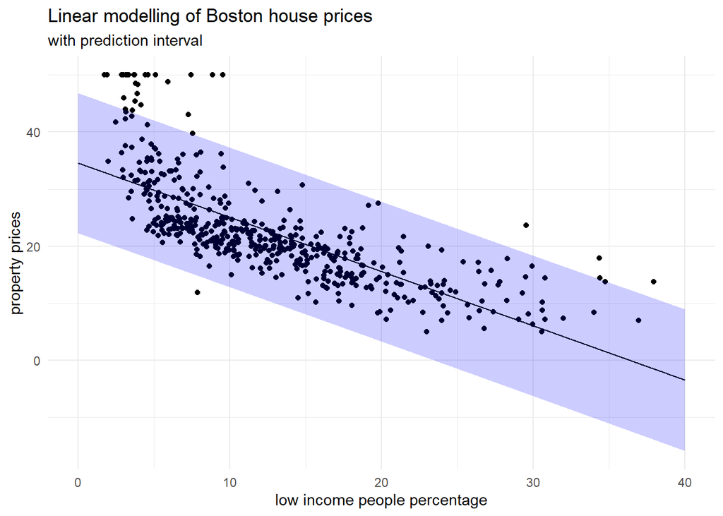

```r
Boston %>%
  ggplot(aes(x = lstat, y = medv)) +
  geom_point() +
  geom_line(data = preds) +
  geom_ribbon(aes(ymin = lower, ymax = upper), data = preds_pred, fill = "blue", alpha = 0.2) +
  labs(title = "Linear modelling of Boston house prices",
       x = "low income people percentage",
       y = "property prices",
       subtitle = "with prediction interval") +
  theme_minimal()
```

Prediction interval is far wider than confidence interval. This is understandable, since there are many points, hence the best fit model is quite constrained and its confidence interval is narrow. But at the same time the data is noisy, so a single new individual prediction can vary a lot (epsilon term - irreducible error in the model equation).

16. **Write a function called `mse()` that takes in two vectors: true y values and predicted y values, and which outputs the mean square error.**

```r
mse <- function(y_true, y_pred) {
  mean( (y_true - y_pred) ^ 2)
}
```

17. **Make sure your `mse()` function works correctly by running the following code.**

```r
mse(1:10, 10:1)
```

```
## [1] 33
```

18. **Calculate the mean square error of the `lm_ses` model. Use the `medv` column as `y_true` and use the `predict()` method to generate `y_pred`.**

```r
mse(Boston$medv, predict(lm_ses))
```

```
## [1] 38.48297
```

19. **The `Boston` dataset has 506 observations. Use `c()` and `rep()` to create a vector with 253 times the word “train”, 152 times the word “validation”, and 101 times the word “test”. Call this vector `splits`.**

```r
splits <- c(rep.int("train", 253), rep.int("validation", 152), rep.int("test", 101))
```

20. **Use the function `sample()` to randomly order this vector and add it to the `Boston` dataset using `mutate()`. Assign the newly created dataset to a variable called `boston_master`.**

```r
boston_master <- Boston %>%
  mutate(split = sample(splits))
head(boston_master)
```

```
##      crim zn indus chas   nox    rm  age    dis rad tax ptratio  black lstat
## 1 0.00632 18  2.31    0 0.538 6.575 65.2 4.0900   1 296    15.3 396.90  4.98
## 2 0.02731  0  7.07    0 0.469 6.421 78.9 4.9671   2 242    17.8 396.90  9.14
## 3 0.02729  0  7.07    0 0.469 7.185 61.1 4.9671   2 242    17.8 392.83  4.03
## 4 0.03237  0  2.18    0 0.458 6.998 45.8 6.0622   3 222    18.7 394.63  2.94
## 5 0.06905  0  2.18    0 0.458 7.147 54.2 6.0622   3 222    18.7 396.90  5.33
## 6 0.02985  0  2.18    0 0.458 6.430 58.7 6.0622   3 222    18.7 394.12  5.21
##   medv      split
## 1 24.0      train
## 2 21.6      train
## 3 34.7 validation
## 4 33.4 validation
## 5 36.2       test
## 6 28.7 validation
```

21. **Now use `filter()` to create a training, validation, and test set from the `boston_master` data. Call these datasets `boston_train`, `boston_valid`, and `boston_test`.**

```r
boston_train <-
  boston_master %>%
  filter(split == "train")

boston_valid <-
  boston_master %>%
  filter(split == "validation")

boston_test <-
  boston_master %>%
  filter(split == "test")
```

22. **Train a linear regression model called `model_1` using the training dataset. Use the formula `medv ~ lstat` like in the first `lm()` exercise. Use `summary()` to check that this object is as you expect.**

```r
model_1 <- boston_train %$% lm(medv ~ lstat)
summary(model_1)
```

```
##
## Call:
## lm(formula = medv ~ lstat)
##
## Residuals:
##    Min     1Q Median     3Q    Max
## -9.964 -4.006 -1.074  2.268 23.819
##
## Coefficients:
##             Estimate Std. Error t value Pr(>|t|)
## (Intercept) 34.96678    0.77425   45.16   <2e-16 ***
## lstat       -0.98938    0.05315  -18.61   <2e-16 ***
## ---
## Signif. codes:  0 '***' 0.001 '**' 0.01 '*' 0.05 '.' 0.1 ' ' 1
##
## Residual standard error: 6.034 on 251 degrees of freedom
## Multiple R-squared:  0.5799, Adjusted R-squared:  0.5783
## F-statistic: 346.5 on 1 and 251 DF,  p-value: < 2.2e-16
```

23. **Calculate the MSE with this object. Save this value as `model_1_mse_train`.**

```r
model_1_mse_train <-
  mse(boston_train$medv, predict(model_1))
model_1_mse_train
```

```
## [1] 36.12051
```

24. **Now calculate the MSE on the validation set and assign it to variable `model_1_mse_valid`. Hint: use the `newdata` argument in `predict()`.**

```r
model_1_mse_valid <-
  mse(y_true = boston_valid$medv, y_pred = predict(model_1, newdata = boston_valid))
model_1_mse_valid
```

```
## [1] 40.77366
```

25. **Create a second model `model_2` for the train data which includes `age` and `tax` as predictors. Calculate the train and validation MSE.**

```r
model_2 <- boston_train %$% lm(medv ~ lstat + age + tax)
#summary(model_2)
```

```r
model_2_mse_train <-
  mse(boston_train$medv, y_pred = predict(model_2))

model_2_mse_valid <-
  mse(boston_valid$medv, y_pred = predict(model_2, newdata = boston_valid))
```

26. **Compare model 1 and model 2 in terms of their training and validation MSE. Which would you choose and why?**

```r
print(c(model_1_mse_train, model_1_mse_valid))
```

```
## [1] 36.12051 40.77366
```

```r
print(c(model_2_mse_train, model_2_mse_valid))
```

```
## [1] 34.84269 37.59086
```

27. **Calculate the test MSE for the model of your choice in the previous question. What does this number tell you?**

```r
model_1_mse_test <-
  mse(y_true = boston_test$medv, y_pred = predict(model_1, newdata = boston_test))
model_1_mse_test
```

```
## [1] 41.38367
```

28. **Create a function that performs k-fold cross-validation for linear models.**

    Inputs:
    - `formula`: a formula just as in the `lm()` function
    - `dataset`: a data frame
    - `k`: the number of folds for cross validation
    - any other arguments you need necessary

    Outputs:
    - Mean square error averaged over folds

```r
# just testing something
formul <- y~x
as.character(formul)
```

```
## [1] "~" "y" "x"
```

```r
 k_fold_cv <- function(formula, dataset, k) {

  # reshuffle the dataset, just in case...
  dataset <- sample(dataset)

  n = nrow(dataset)
  mses = rep(1:k)                             # mean square errors for each fold
  fold = rep(1:k, length.out = n)             # fold label for each row of dataset
  dataset <- dataset %>% mutate(fold = fold)

  for (i in 1:k) {

    # split s.t. i-th fold is used for validation, all the rest for training
    data_train <- dataset %>% filter(fold != i)
    data_valid <- dataset %>% filter(fold == i)

    # build model on remaining k-1, and predict on i-th fold
    lm_this <- lm(formula, data_train)
    y_pred <- predict(lm_this, newdata = data_valid)

    # access the y-variable name from formula to extract it from the validation set
    name_of_y_var <- as.character(formula)[2]
    y_true <- data_valid[[name_of_y_var]]

    # calculate MSE corresponding to i-th fold
    mses[i] <- mse(y_true, y_pred)
  }

  # this function returns the MEAN of MSE values acroos all k folds:
  mean(mses)
}
```

29. **Use your function to perform 9-fold cross validation with a linear model with as its formula `medv ~ lstat + age + tax`. Compare it to a model with as formulat `medv ~ lstat + I(lstat^2) + age + tax`.**

```r
k_fold_cv(formula = medv ~ lstat + age + tax, dataset = Boston, k = 9 )
```

```
## [1] 37.55997
```

```r
k_fold_cv(formula = medv ~ lstat + I(lstat^2) + age + tax, dataset = Boston, k = 9 )
```

```
## [1] 28.03839
```

A more complex model yields lower MSE because it can fit the data better.

```r
head(Boston$medv)
```

```
## [1] 24.0 21.6 34.7 33.4 36.2 28.7
```

```r
# this will fail
#head(Boston[medv])
```

```r
head(Boston["medv"])
```

```
##   medv
## 1 24.0
## 2 21.6
## 3 34.7
## 4 33.4
## 5 36.2
## 6 28.7
```

```r
head(Boston[["medv"]])
```

```
## [1] 24.0 21.6 34.7 33.4 36.2 28.7
```